# Séries_Temporais - Gráficos_para_Sazonalidade

Matheus Machado de Almeida

11/06/2021

Além da decomposição apresentada no post Séries Temporais: Introdução e Decomposição dos Componentes em R, há outras formas de visualizar a sazonalidade da série. A séries utilizada aqui é a a10 do pacote fpp, e que contém as informações de venda de antibióticos na Austrália no período de 1991 a 2008.

Começamos com um gráfico simples da série:

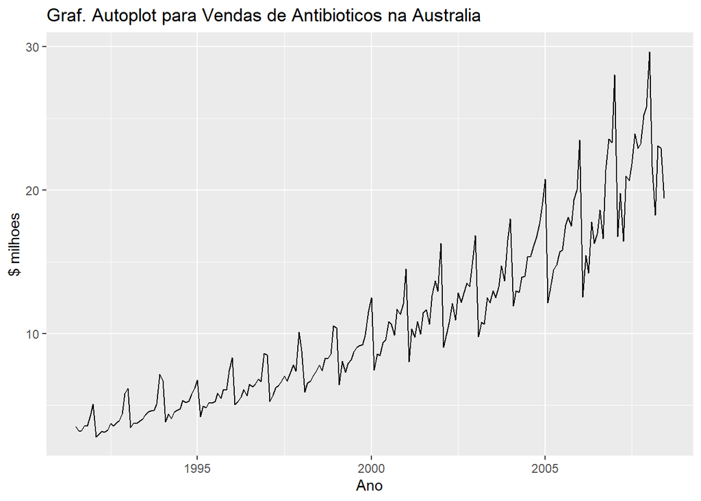

```r
autoplot(a10) +
  ggtitle("Graf. Autoplot para Vendas de Antibioticos na Australia") +
  ylab("$ milhoes") +
  xlab("Ano")
```

Em seguida, traçamos um gráfico de sazonalidade com a função seasonplot():

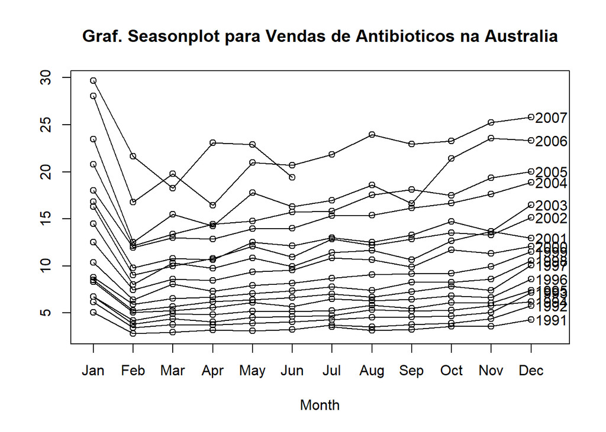

```r
# Grafico de sazonalidade
seasonplot(a10,
           year.labels=TRUE,
           main="Graf. Seasonplot para Vendas de Antibioticos na Australia")
```

Como você pode ver, temos as linhas ano a ano confrontadas. É um gráfico simples de séries, porém com a sazaonalidade confrontada. Podemos observar, por exemplo, que a venda de antibióticos cresce de fevereiro a março, e que janeiro é o pico de vendas. Esse comportamento é padrão para todos os anos, com exceção de 2008. Pode ser o caso dos dados não terem sido completamente coletados (visto que o ano está incompleto).

É possível deixar o gráfico um pouco melhor, com alguns detalhes para facilitar a visualização. Em outras palavras, deixar mais bonito:

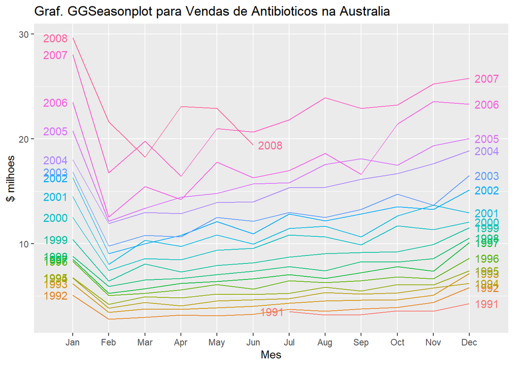

```r
# Grafico de sazonalidade com mais detalhes
ggseasonplot(a10,
             year.labels = TRUE,
             year.labels.left = TRUE) +
  ylab("$ milhoes") +
  xlab("Mes") +
  ggtitle("Graf. GGSeasonplot para Vendas de Antibioticos na Australia")
```

Outra opção bacana no ggseasonplot() é fazer um gráfico polar:

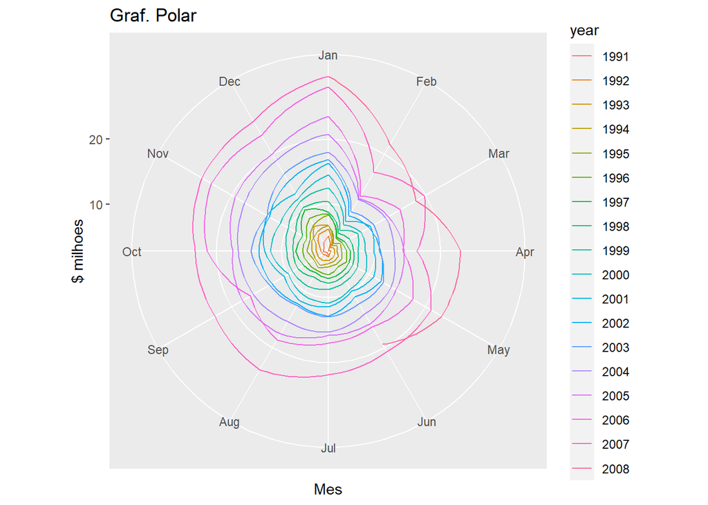

```r
ggseasonplot(a10, polar=TRUE) +
  ylab("$ milhoes") +
  xlab("Mes") +
  ggtitle("Graf. Polar")
```

Por fim, você pode comparar as diferentes estações por mês. No gráfico abaixo, temos as séries divididas pelos meses com o traço azul indicando a média de cada um:

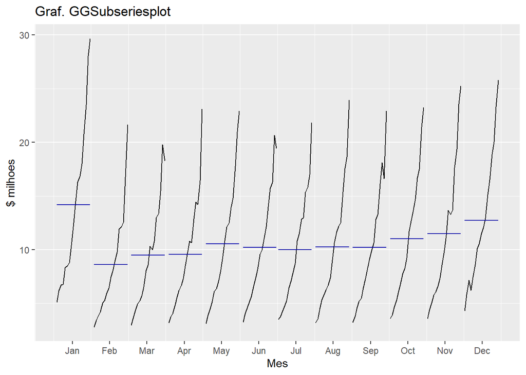

```r
ggsubseriesplot(a10) +
      ylab("$ milhoes") +
      xlab("Mes")+
      ggtitle("Graf. GGSubseriesplot")
```